# Riparian Invertebrates: Investigate Methods - v.2

```r
# packages
library(knitr)
library(tidyverse)
library(readxl)
library(forcats)
library(vegan)
```

## Field data

Import previously prepared field data. This comprises a series of sampling events collated by Jon Webb.

Here are 10 random rows from the data:

```r
field_data <- read_csv("../data/field_data_extract.csv")
sample_n(field_data, size = 10) #%>% kable()
```

| spp_name | river | event_code | date | sample_type | location | smpshort | locshort | replicate |
| --- | --- | --- | --- | --- | --- | --- | --- | --- |
| Poecilus cupreus | Wye | Wye_2014_6 | 30/10/2014 | hand_search | 6B | HS | 6B | Wye_2014_6-HS-6B |
| Agonum muelleri | Wye | Wye_2014_4 | 01/06/2015 | pitfall | 4B | PF | 4B | Wye_2014_4-PF-4B |
| Bembidion tetracolum | Wye | Wye_2014_7 | 31/10/2014 | hand_search | 7B | HS | 7B | Wye_2014_7-HS-7B |
| Dianous coerulescens | Wooler Water | Wooler_2013 | 12/06/2013 | hand_search | JRW 3 | HS | JRW3 | Wooler_2013-HS-JRW3 |
| Pterostichus anthracinus | Lugg | Lugg_2014_1 | 01/06/2015 | pitfall | 1C | PF | 1C | Lugg_2014_1-PF-1C |
| Phylhygra malleus | Dove | Dove_2013 | NA | hand_search | 2 | HS | 2 | Dove_2013-HS-2 |
| Lesteva longoelytrata | Wooler Water | Wooler_2013 | 12/06/2013 | hand_search | NM 2 | HS | NM2 | Wooler_2013-HS-NM2 |
| Aleochara bipustulata | Wye | Wye_2014_6 | 01/06/2015 | pitfall | 6D | PF | 6D | Wye_2014_6-PF-6D |
| Anotylus rugosus | Wye | Wye_2014_5 | 11/06/2015 | hand_search | 5B | HS | 5B | Wye_2014_5-HS-5B |
| Carpelimus manchurius | Dove | Dove_2013 | NA | hand_search | 3 | HS | 3 | Dove_2013-HS-3 |

Each species record is a row. Columns are species name (`spp_name` and columns identifying the survey event.

The data is nested as follows:

- `river`
- `event_code`
- `sample_type`
- `location`
- `spp_name` (= observation)

### Replication

For this data we have conceptualised a replicate as being a single sampling occasion, e.g. a set of pitfall traps (from being set to being retrieved), a timed hand search or a timed excavation. A replicate is equivalent to an ‘effort’, discussed further below. In some cases JW constructed replicates retrospectively, i.e. combined a number of observations that were taken at a particular time and place.

`event_code`, `sample_type` and `location` have therefore been combined into a single field `replicate`. So the each record can be uniquely identified by replicate and observation:

- `replicate`
- `spp_name`

This is a post-hoc stratification of the sample and may not represent the actual sampling methodology in many cases and may introduce bias.

```r
field_data %>%  group_by(event_code, sample_type) %>%
  group_by(event_code, sample_type) %>%
  summarise(n_repl = length(unique(location))) %>%
  group_by(sample_type) %>%
  summarise(sum(n_repl))
```

| sample_type | sum(n_repl) |
| --- | --- |
| excavation | 19 |
| hand_search | 69 |
| pitfall | 38 |

```r
  #spread(key = sample_type, value = n_repl, fill = " ") %>%
```

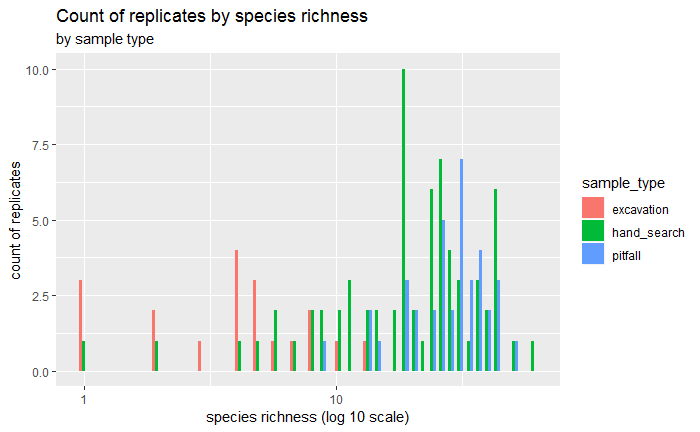

```r
# graphdata <- field_data %>% group_by(replicate = repl_dateloc, sample_type) %>%
#   summarise(n = length(spp_name)) %>% mutate(repl_type = "repl_dateloc")
#
# graphdata <- field_data %>% group_by(replicate = repl_date, sample_type) %>%
#   summarise(n = length(spp_name)) %>% mutate(repl_type = "repl_date") %>%
#   bind_rows(graphdata)
graphdata <- field_data %>% group_by(replicate, sample_type) %>%
  summarise(n = length(spp_name))
# %>% bind_rows(graphdata)
ggplot(graphdata, aes(x = n)) +
  geom_histogram(aes(fill = sample_type), position = "dodge", bins = 50)+
  scale_x_log10() +
  labs(title = "Count of replicates by species richness",
       subtitle = "by sample type",
       x = "species richness (log 10 scale)", y = "count of replicates")
```

### Sampling effort data

Sampling effort data is available from a study of the reported methodologies for each survey and have been compiled for analysis. An extract of the data is shown below. `effort_P` represents the number of pitfall trap samples. Note it does not represent the number of actual traps, rather a set of traps (quantity given in `n_pitfall` if known), set out for a period of time, e.g. 2 weeks, counts as 1 ‘effort’. `effort_T` represents the number of timed samples, both a timed hand search and a timed excavation count as 1 ‘effort’. `effort_combined` is simply the sum of `effort_P` and `effort_T`. The other columns are not currently being used for analysis (and I’m afraid the time period columns have been mangled in transition from excel to R - its possible to fix that, but wasn’t a priority).

```r
effort_data <- read_csv("../data/effort_data_extract.csv")
effort_data%>%
  kable(caption = "Reported effort", format="pandoc")
```

Reported effort

| event_code | author | effort_P | effort_T |
| --- | --- | --- | --- |
| Wye_2014_5 | Henshall et al | 0 | 2 |
| Lugg_2014_2 | Henshall et al | 2 | 3 |
| Lugg_2014_1 | Henshall et al | 4 | 4 |
| Lugg_2014_3 | Henshall et al | 4 | 4 |
| Lugg_2014_4 | Henshall et al | 4 | 4 |
| Wye_2014_4 | Henshall et al | 4 | 4 |
| Wye_2014_6 | Henshall et al | 4 | 4 |
| Wye_2014_7 | Henshall et al | 4 | 4 |
| Wye_2014_3 | Henshall et al | 4 | 5 |
| Breamish_2013 | Webb & Mott | 1 | 8 |
| Till_2013_lower | Webb & Mott | 1 | 8 |
| Till_2013_upper | Webb & Mott | 1 | 4 |
| Trent | Webb & Mott | 0 | 7 |
| Tweed_2013 | Webb & Mott | 0 | 4 |
| Wye_2014_1 | Webb & Mott | 1 | 8 |
| Dove_2013 | Webb & Mott | 2 | 4 |
| Wooler_2013 | Webb & Mott | 1 | 8 |
| Monnow_2015 | Webb & Mott | 1 | 4 |

The effort counts are in fact the same thing as the number of replicates of each sample type. Unfortunately, they don’t correspond well with the inferred replicates discussed above.

```r
 efforttemp <- effort_data %>% select(event_code, effort_P, effort_T) %>%
  mutate(repl_type = "method")
effort_analysis <- field_data %>%
  select(event_code, sample_type, replicate) %>%
  group_by(event_code, sample_type) %>%
  summarise(n = length(unique(replicate))) %>%
  spread(key = sample_type, value = n, fill = 0) %>%
  mutate(effort_T = excavation+hand_search, effort_P = pitfall) %>%
   select(event_code, effort_P, effort_T) %>%
  mutate(repl_type = "data")
effort_analysis <- effort_analysis%>%
   bind_rows(efforttemp) %>%
   mutate(effort_comb = effort_P + effort_T) %>%
   gather(key = sample_type, value = n, effort_P, effort_T, effort_comb)
 rm(efforttemp)
```

Here is the difference between the reported method and the replicates found in the data:

```r
#head(effort_analysis)
effort_diff <- effort_analysis %>%
  spread(key = repl_type, value = n, fill = 0) %>%
  mutate(diff = data-method) %>%
  arrange(-abs(diff))
effort_diff %>% select(event_code, sample_type, diff) %>% spread(key = sample_type, value = diff) %>%
  select(event_code, effort_P, effort_T)%>%
  kable(caption = "Reported effort subtracted from actual effort", format="pandoc")
```

Reported effort subtracted from actual effort

| event_code | effort_P | effort_T |
| --- | --- | --- |
| Breamish_2013 | 0 | 0 |
| Dove_2013 | -1 | 4 |
| Lugg_2014_1 | 0 | 0 |
| Lugg_2014_2 | 0 | -1 |
| Lugg_2014_3 | 0 | 0 |
| Lugg_2014_4 | 0 | 0 |
| Monnow_2015 | 0 | 4 |
| Till_2013_lower | 0 | -4 |
| Till_2013_upper | -1 | 3 |
| Trent | 0 | -3 |
| Tweed_2013 | 1 | 4 |
| Wooler_2013 | 0 | -4 |
| Wye_2014_1 | 1 | -4 |
| Wye_2014_3 | 0 | 0 |
| Wye_2014_4 | 0 | 0 |
| Wye_2014_5 | 0 | 0 |
| Wye_2014_6 | 0 | 0 |
| Wye_2014_7 | 0 | 0 |

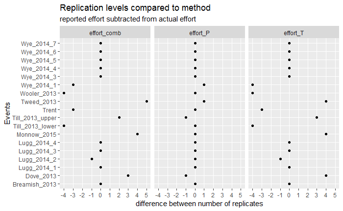

```r
ggplot(effort_diff,# %>% filter(sample_type == "effort_P"),
       aes(y = event_code, x = diff)) +
  geom_point(aes()) +
 scale_x_continuous(breaks = c(-5, -4, -3, -2, -1, 0, 1, 2, 3, 4, 5), minor_breaks = NULL) +
  labs(title = "Replication levels compared to method",
       subtitle = "reported effort subtracted from actual effort",
       y = "Events", x = "difference between number of replicates") +
    facet_wrap(~sample_type, ncol = 3)
```

```r
NA
```

## Create frequency matrix

This matrix calculates the frequency each species occurs in each replicate.  
- because it’s by ‘replicate’ each species should only occur once, so in this case the frequency matrix is the same as an occurrence matrix.

```r
#convert to a frequency matrix
field_data_freq <- field_data %>%
  #calculate frequencies
  group_by(river, replicate, event_code, location, sample_type, spp_name) %>%
  summarise(n = length(spp_name)) %>%
  #abbreviate species names
  mutate(spp_name = vegan::make.cepnames(spp_name)) %>%
  #spread to a matrix
  spread(key = spp_name, value = n, fill = 0) %>%
  data.frame() %>%
  arrange(river)
#field_data_freq
sample_n(field_data_freq, size = 10)[,1:5] %>%
  kable(caption = "Sample of frequency matrix: only one species column shown", format="pandoc")
```

|  | river | replicate | event_code | location | sample_type |
| --- | --- | --- | --- | --- | --- |
| 116 | Wye | Wye_2014_6-PF-6B | Wye_2014_6 | 6B | pitfall |
| 40 | Lugg | Lugg_2014_4-HS-4B | Lugg_2014_4 | 4B | hand_search |
| 51 | Monnow | Monnow_2015-HS-1b | Monnow_2015 | 1b | hand_search |
| 33 | Lugg | Lugg_2014_3-HS-3C | Lugg_2014_3 | 3C | hand_search |
| 50 | Monnow | Monnow_2015-HS-1A | Monnow_2015 | 1A | hand_search |
| 121 | Wye | Wye_2014_7-HS-7C | Wye_2014_7 | 7C | hand_search |
| 38 | Lugg | Lugg_2014_3-PF-3D | Lugg_2014_3 | 3D | pitfall |
| 8 | Breamish | Breamish_2013-HS-NM4 | Breamish_2013 | NM 4 | hand_search |
| 91 | Wye | Wye_2014_1-PF-site1pit2 | Wye_2014_1 | site 1 pit 2 | pitfall |
| 74 | Tweed | Tweed_2013-EX-Fishingarea1 | Tweed_2013 | Fishing area 1 | excavation |

## Species accumulation curves

In this section I’ll start looking at species accumulation curves, with an emphasis on methodological differences. Initially I’ll be comparing different ways of subdividing the data (mainly by sample type and/or replicate).

```r
event_code_selected <- unique(field_data$event_code)
# event_code_selected <- c("Wye_2014_5", "Beamish_2013", "Dove_2013", "Lugg_2014_2", "Monnow_2015", "FromeMoreton_2017", "FromeRushton_2017", "FromeWoodsford_2017", "Till_2013", "Wooler_2013", "Wye_2014_1", "Lugg_2014_1", "Lugg_2014_3", "Lugg_2014_4", "Wye_2014_4", "Wye_2014_6", "Wye_2014_7", "Wye_2014_3")
```

The following events have been selected for analysis: Wye_2014_6, Lugg_2014_3, Lugg_2014_1, Lugg_2014_2, Lugg_2014_4, Wye_2014_3, Wye_2014_7, Wye_2014_4, Wye_2014_5, Breamish_2013, Monnow_2015, Till_2013_lower, Trent, Tweed_2013, Wye_2014_1, Dove_2013, Till_2013_upper, Wooler_2013

### Grand total accumulation

This doesn’t really tell us a lot, except that combining all sampling methods and all surveys doesn’t reach an asymptote. Because this covers a number of rivers and surveys, I’m not sure we need to read much into this.

```r
#species accumulation curve by resampling events
selected_data <- field_data_freq %>%
  select(-c(river:sample_type))
spec_accum_selected <- specaccum(comm = selected_data)
plot(spec_accum_selected, ci.type = "polygon", ci.col = "grey", ci.lty = "dotted",
     main = "Species accumulation curve: grand total")
abline(h = max(spec_accum_selected$richness), col = "black")
```

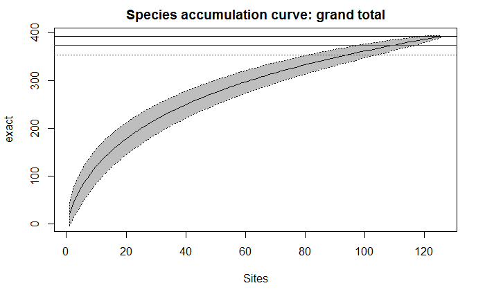

```r
abline(h = max(spec_accum_selected$richness)*0.95, col = "red")
abline(h = max(spec_accum_selected$richness)*0.9, col = "red", lty = "dotted")
```

### Sample type accumulation

Here we’ll look at species accumulation curves by sample type.

```r
param_sampletype <- c("excavation", "hand_search", "pitfall")
param_eventcode <- event_code_selected
#create empty data frame
spec_accum_bysampletype <- data_frame(sample_type = as.character(), event_code = as.character(),
  n_sites = as.integer(), n_spp = as.double(), sd = as.double())
for(sampletype in param_sampletype){

    tempdata <- field_data_freq %>%
      filter(sample_type == sampletype) %>%
      select(-c(river:sample_type))

    tempdata <- if(nrow(tempdata)>1){

      tempdata <- specaccum(tempdata)

      tempdata <- data.frame(
        sample_type = sampletype,
        n_sites = tempdata$sites,
        n_spp = tempdata$richness,
        sd = tempdata$sd)

      spec_accum_bysampletype <- rbind(spec_accum_bysampletype, tempdata)}
  }
spec_accum_bysampletype <- spec_accum_bysampletype %>%
  mutate(event_code = "all_events", river = "all_rivers") %>%
  select(river, event_code, sample_type, everything())
```

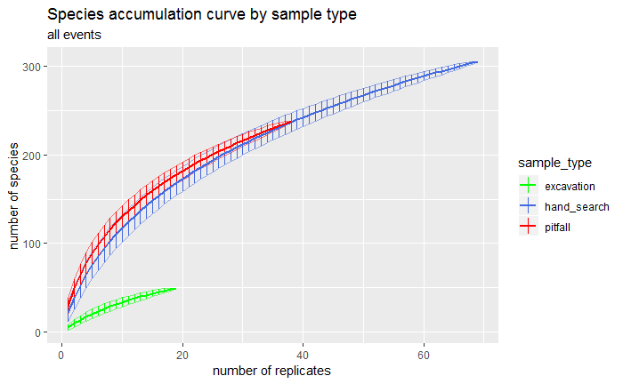

```r
graphdata <- spec_accum_bysampletype
colours <- c("hand_search" = "royalblue", "excavation" = "green", "pitfall" = "red")
ggplot(graphdata, aes(x = n_sites, y = n_spp, colour = sample_type))+
    geom_path(aes(y = n_spp-sd), alpha = 0.5) +
    geom_path(aes(y = n_spp+sd), alpha = 0.5) +
    geom_linerange(aes(ymin = n_spp-sd, ymax = n_spp+sd)) +
    geom_line(size = 1) +
    scale_color_manual(values = colours)+
    labs(title = "Species accumulation curve by sample type",
         subtitle = "all events",
         x = "number of replicates", y = "number of species",
         NULL) +
    NULL
```

### Accumulation by event

```r
param_sampletype <- c("excavation", "hand_search", "pitfall")
param_rivers <- unique(field_data_freq$river)
param_eventcode <- event_code_selected
#create empty data frame
spec_accum_temp <- data_frame(
  sample_type = as.character(),
  #river = as.character(),
  event_code = as.character(),
  n_sites = as.integer(), n_spp = as.double(), sd = as.double())
spec_accum_byevent <- spec_accum_temp
# #iterate through rivers
# for(selectedriver in param_rivers){
#iterate through events
for(selectedevent in param_eventcode){
  #iterate through samples
  for(sampletype in param_sampletype){

    tempdata <- field_data_freq %>%
      filter(sample_type == sampletype &
               event_code == selectedevent) %>%
      select(-c(river:sample_type))

    tempdata <- if(nrow(tempdata)>1){

      tempdata <- specaccum(tempdata)

      tempdata <- data.frame(
        sample_type = sampletype,
        event_code = selectedevent,
        n_sites = tempdata$sites,
        n_spp = tempdata$richness,
        sd = tempdata$sd)

      spec_accum_temp <- rbind(spec_accum_temp, tempdata)}
  }
  spec_accum_byevent <-  if(nrow(spec_accum_temp)>0){rbind(spec_accum_byevent, spec_accum_temp)}
}
```

[output not shown]

```r
spec_accum_byevent <-  spec_accum_byevent %>%
  mutate(river = recode_factor(event_code,
                                Wye_2014_6 = "Wye",
                               Lugg_2014_3 = "Lugg",
                               Lugg_2014_1 = "Lugg",
                               Lugg_2014_2 = "Lugg",
                               Lugg_2014_4 = "Lugg",
                               Wye_2014_3 = "Wye",
                               Wye_2014_7 = "Wye",
                               Wye_2014_4 = "Wye",
                               Wye_2014_5 = "Wye",
                               Breamish_2013 = "Breamish", Monnow_2015 = "Monnow", Till_2013_lower = "Till", Trent = "Trent", Tweed_2013 = "Tweed", Wye_2014_1 = "Wye", Dove_2013 = "Dove", Till_2013_upper = "Till",  Wooler_2013 = "Wooler")) %>%
  select(river, event_code, sample_type, everything())
```

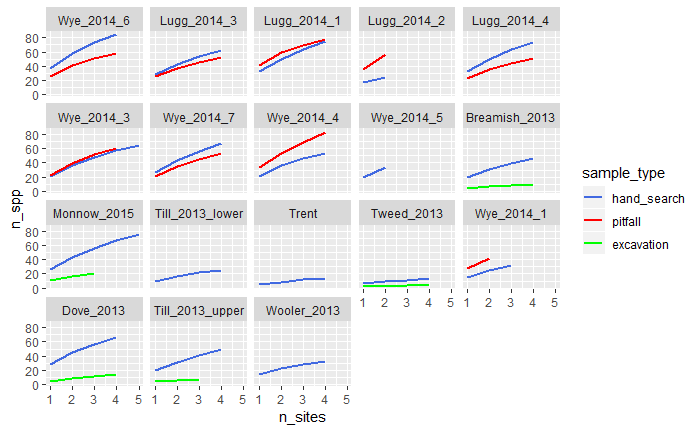

```r
graphdata <- spec_accum_byevent
colours <- c("hand_search" = "royalblue", "excavation" = "green", "pitfall" = "red")

ggplot(graphdata, aes(x = n_sites, y = n_spp, colour = sample_type))+
  geom_line(size = 1) +
  scale_color_manual(values = colours)+
  scale_x_continuous(breaks = 1:max(graphdata$n_sites))+
  facet_wrap(~event_code)+
  NULL
```

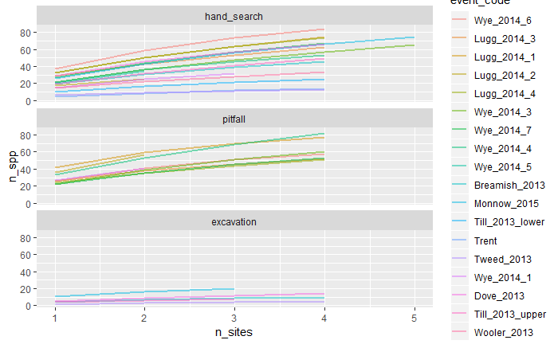

```r
graphdata <- spec_accum_byevent
ggplot(graphdata, aes(x = n_sites, y = n_spp))+
  geom_line(size = 1, aes(colour = event_code), alpha = 0.5) +
 # geom_smooth()+
  facet_wrap(~sample_type, ncol = 1)+
  NULL
```

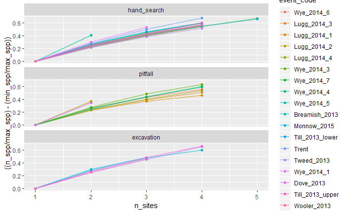

```r
maxmin <- spec_accum_byevent %>% group_by(event_code, sample_type) %>%
  summarise(max_spp = max(n_spp), min_spp = min(n_spp))
graphdata <- spec_accum_byevent %>% full_join(maxmin)
ggplot(graphdata, aes(x = n_sites,
                      y = ((n_spp/max_spp)-(min_spp/max_spp)),
                      colour = event_code))+
  geom_point()+
  geom_line(size = 1, alpha = 0.5) +
  facet_wrap(~sample_type, ncol = 1)+
  NULL
```

### Accumulation combining pitfall and handsearch

```r
selected_data <- HSPF_freq %>% select(-c(river:location))
spec_accum_HSPF_all <- specaccum(comm = selected_data)
```

```
the standard deviation is zero
```

```r
# plot(spec_accum_HSPF_all, ci.type = "polygon", ci.col = "grey", ci.lty = "dotted",
#      main = "Species accumulation curve: grand total")
spec_accum_HSPF_all <- data.frame(
      river = "Wye & Lugg",
      event_code = "HSPF_events",
      sample_type = "HS & PF",
      n_sites = spec_accum_HSPF_all$sites,
      n_spp = spec_accum_HSPF_all$richness,
      sd = spec_accum_HSPF_all$sd)
```

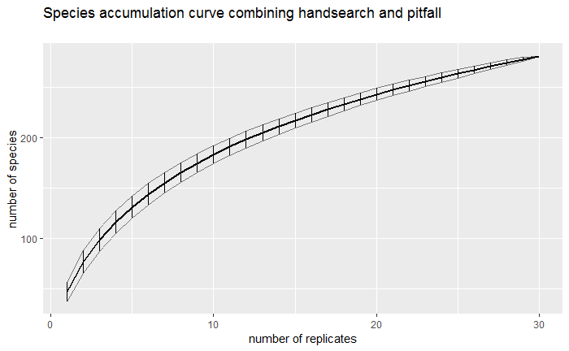

```r
graphdata <- spec_accum_HSPF_all
colours <- c("hand_search" = "royalblue", "excavation" = "green", "pitfall" = "red")
ggplot(graphdata, aes(x = n_sites, y = n_spp))+
    geom_path(aes(y = n_spp-sd), alpha = 0.5) +
    geom_path(aes(y = n_spp+sd), alpha = 0.5) +
    geom_linerange(aes(ymin = n_spp-sd, ymax = n_spp+sd)) +
    geom_line(size = 1) +
    labs(title = "Species accumulation curve combining handsearch and pitfall",
         subtitle = "",
         x = "number of replicates", y = "number of species",
         NULL) +
    NULL
```

```r
param_rivers <- unique(HSPF_freq$river)
#create empty data frame
spec_accum_temp <- data_frame(
  river = as.character(),
  n_sites = as.integer(), n_spp = as.double(), sd = as.double())
spec_accum_HSPF_byriver <- spec_accum_temp
#iterate through events
for(selectedriver in param_rivers){
  tempdata <- HSPF_freq  %>%
    filter(river == selectedriver) %>%
    select(-c(river:location))

  tempdata <- if(nrow(tempdata)>1){

    tempdata <- specaccum(tempdata)

    tempdata <- data.frame(
      river = selectedriver,
      n_sites = tempdata$sites,
      n_spp = tempdata$richness,
      sd = tempdata$sd)

    spec_accum_HSPF_byriver <-  if(nrow(tempdata)>0){rbind(spec_accum_HSPF_byriver, tempdata)}
  }
}
```

```
the standard deviation is zerothe standard deviation is zero
```

```r
spec_accum_HSPF_byriver <- spec_accum_HSPF_byriver %>%
  mutate(event_code = "HSPF_events", sample_type = "HS & PF") %>%
  select(river, event_code, sample_type, everything())
```

```r
graphdata <- bind_rows(spec_accum_HSPF_byriver, spec_accum_HSPF_all)
```

[output not shown]

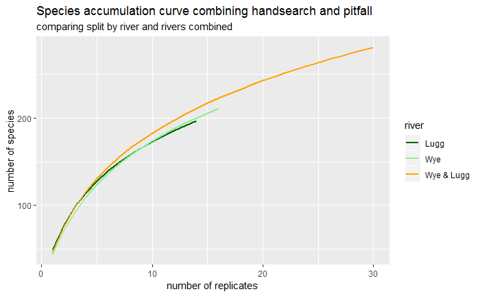

```r
colours <- c("Wye" = "lightgreen", "Lugg" = "darkgreen", "Wye & Lugg" = "orange")
ggplot(graphdata, aes(x = n_sites, y = n_spp))+
  geom_line(size = 1, aes(colour = river)) +
  scale_colour_manual(values = colours) +
#  facet_wrap(~sample_type) +
      labs(title = "Species accumulation curve combining handsearch and pitfall",
         subtitle = "comparing split by river and rivers combined",
         x = "number of replicates", y = "number of species",
         NULL) +
  NULL
```

### All together

```r
graphdata <- bind_rows(spec_accum_HSPF_all, spec_accum_bysampletype)
```

[output not shown]

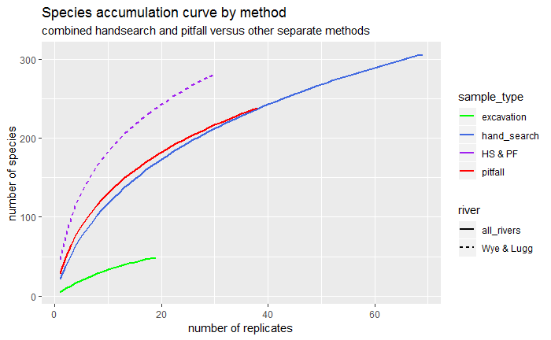

```r
colours <- c("hand_search" = "royalblue", "excavation" = "green",
             "pitfall" = "red", "HS & PF" = "purple")
ggplot(graphdata, aes(x = n_sites, y = n_spp))+
  geom_line(size = 1, aes(colour = sample_type, linetype = river)) +
  scale_colour_manual(values = colours)+
#  facet_wrap(~sample_type) +
      labs(title = "Species accumulation curve by method",
         subtitle = "combined handsearch and pitfall versus other separate methods",
         x = "number of replicates", y = "number of species",
         NULL) +
  NULL
```